# LGBM : 데이콘-자동차 가격 예측 대회

newhyh

2023-06-24

**분석 개요**

[figure not shown]

**변수 설명**  
ID : 샘플 별 고유 id  
생산년도 : 차량이 생산된 연도  
모델출시년도 : 차량의 모델이 처음으로 출시된 연도  
브랜드  
차량모델명  
판매도시 : 3글자로 인코딩된 도시 이름  
판매구역 : 3글자로 인코딩된 구역 이름  
주행거리 : 총 주행 거리(km)  
배기량 : 내연기관에서 피스톤이 최대로 밀어내거나 빨아들이는 부피 (cc)  
압축천연가스(CNG) : 압축천연가스(CNG) 자동차 여부  
경유 : 경유 자동차 여부  
가솔린 : 가솔린 자동차 여부  
하이브리드 : 하이브리드 자동차 여부  
액화석유가스(LPG) : 액화석유가스(LPG) 자동차 여부  
가격 : 자동차 가격(백만원)

**라이브러리**

```r
library(tidyverse)
library(caret)
library(recipes)
library(rsample)
library(data.table)
library(corrplot)
library(car)
library(psych)
library(lightgbm)
library(tictoc)
library(doParallel)
```

**데이터 불러오기**

```r
path <- "./open/"
dat <- read.csv(file.path(path, "train.csv"),encoding="UTF-8")
```

#### **전처리 및 EDA**

```r
dat %>% summary()
```

[output not shown]

```r
dat %>% str()
```

```
## 'data.frame':    57920 obs. of  15 variables:
##  $ ID               : chr  "TRAIN_00000" "TRAIN_00001" "TRAIN_00002" "TRAIN_00003" ...
##  $ 생산년도         : int  2018 2010 2002 2006 2007 2001 2021 2005 2018 2011 ...
##  $ 모델출시년도     : int  2014 2006 2002 2001 2007 1995 2019 2005 2014 2006 ...
##  $ 브랜드           : chr  "skoda" "toyota" "mercedes-benz" "nissan" ...
##  $ 차량모델명       : chr  "fabia" "auris" "clk-klasa" "x-trail" ...
##  $ 판매도시         : chr  "KAT" "RKO" "GNI" "EHX" ...
##  $ 판매구역         : chr  "SLA" "SWI" "WIE" "WIE" ...
##  $ 주행거리         : int  85231 135000 255223 238000 251000 340000 10 217850 98514 201000 ...
##  $ 배기량           : int  999 1598 1796 2184 1910 1984 999 1595 1000 1560 ...
##  $ 압축천연가스.CNG.: int  0 0 0 0 0 0 0 0 0 0 ...
##  $ 경유             : int  0 0 0 1 1 0 0 0 0 1 ...
##  $ 가솔린           : int  1 1 1 0 0 0 0 1 1 0 ...
##  $ 하이브리드       : int  0 0 0 0 0 0 0 0 0 0 ...
##  $ 액화석유가스.LPG.: int  0 0 0 0 0 1 1 0 0 0 ...
##  $ 가격             : num  51.7 41.5 17.8 18.2 17.6 ...
```

**결측치 확인**

```r
dat %>% is.na() %>% colSums()
```

[output not shown]

결측치 없음

**전처리**

```r
colnames(dat)[10] <- "CNG"
colnames(dat)[14] <- "LNG"
dat <- dat %>% mutate_if(is.character,factor )
dat <- dat %>% select(-ID )
dat$연료 <- rep("없음",nrow(dat))
dat[dat$CNG==1,"연료"] <- "CNG"
dat[dat$경유==1,"연료"] <- "경유"
dat[dat$가솔린==1,"연료"] <- "가솔린"
dat[dat$하이브리드==1,"연료"] <- "하이브리드"
dat[dat$LNG==1,"연료"] <- "LNG"
dat$연료 <- factor(dat$연료)
dat1 <- dat %>% select(-c(CNG,경유,가솔린,하이브리드,LNG))
```

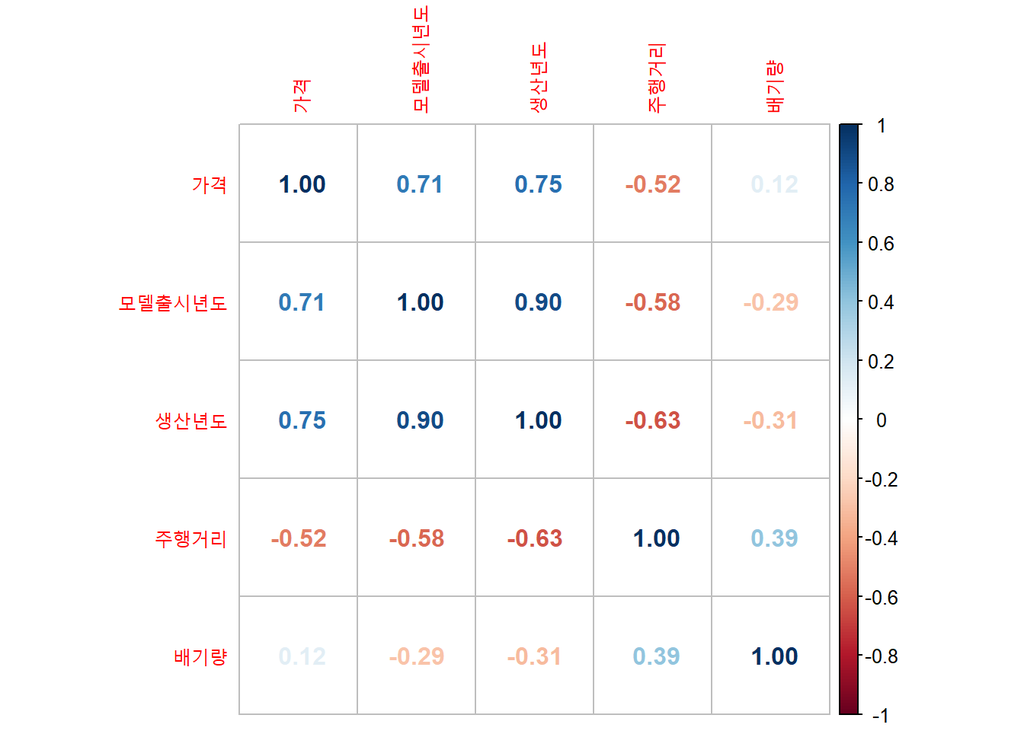

```r
M <- dat1 %>% select_if(is.numeric) %>% cor()
corrplot(M,method="number", order="AOE" )
```

**이상치 확인**

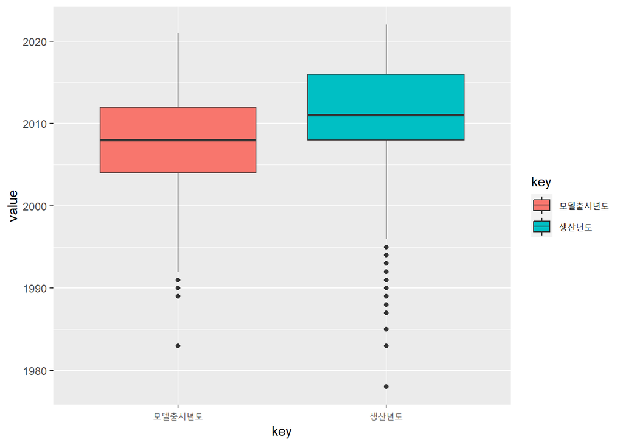

```r
dat1 %>% select(모델출시년도,생산년도) %>% gather() %>% ggplot() +
  geom_boxplot(mapping = aes( x = key , y = value , fill = key ))
```

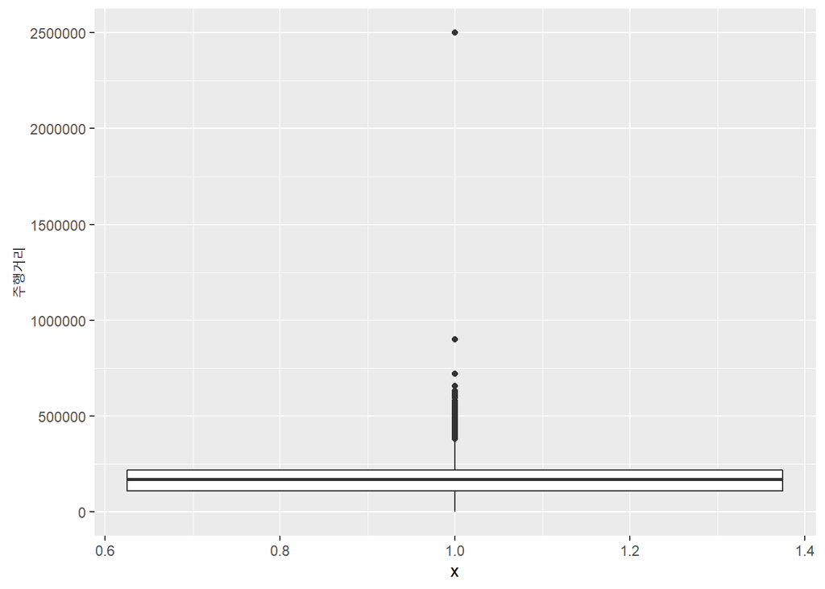

```r
ggplot(dat1, aes(x=1,y=주행거리)) + geom_boxplot()
```

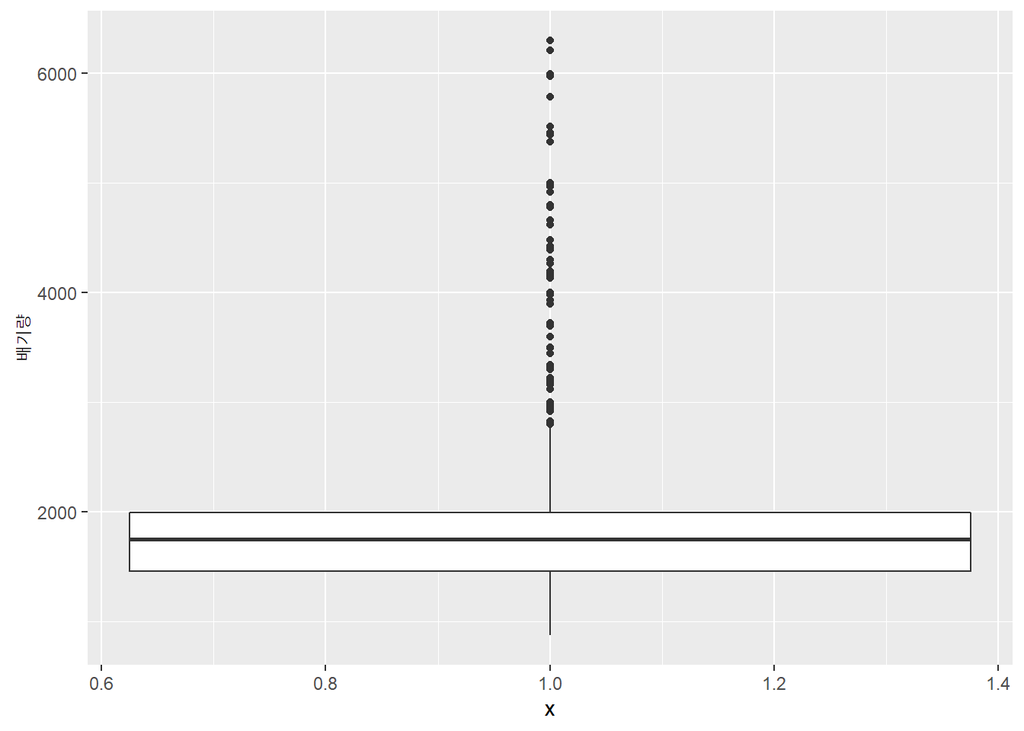

```r
ggplot(dat1, aes(x=1,y=배기량)) + geom_boxplot()
```

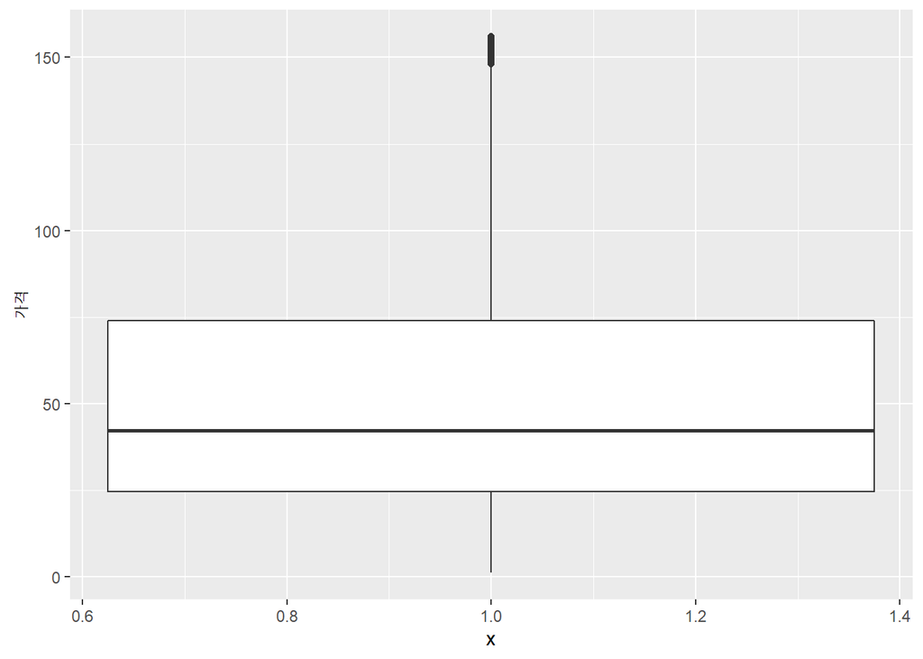

```r
ggplot(dat1, aes(x=1,y=가격)) + geom_boxplot()
```

**배기량 500단위로 묶기**

```r
dat1_1 <- dat1
dat1_1$배기량_1 <- case_when(
  dat1_1$배기량 < 1000 ~ "1000미만",
  dat1_1$배기량 < 1500 ~ "1000_1499",
  dat1_1$배기량 < 2000 ~ "1500_1999",
  dat1_1$배기량 < 2500 ~ "2000_2499",
  dat1_1$배기량 < 3000 ~ "2500_2999",
  dat1_1$배기량 < 3500 ~ "3000_3499",
  dat1_1$배기량 < 4000 ~ "3500_3999",
  dat1_1$배기량 < 4500 ~ "4000_4499",
  dat1_1$배기량 < 5000 ~ "4500_4999",
  dat1_1$배기량 < 5500 ~ "5000_5499",
  dat1_1$배기량 < 6000 ~ "5500_5999",
  dat1_1$배기량 >= 6000 ~ "6000이상" )
```

**주요 변수별 평균 가격 생성**

```r
평균가격_브랜드df <- aggregate(가격~브랜드,dat1_1, mean) %>% arrange(가격)
평균가격_모델df <- aggregate(가격~차량모델명,dat1_1, mean)  %>% arrange(가격)
평균가격_판매도시df <- aggregate(가격~판매도시,dat1_1, mean)  %>% arrange(가격)
평균가격_배기량df <- aggregate(가격~배기량_1,dat1_1, mean)  %>% arrange(가격)
평균가격_연료df <- aggregate(가격~연료,dat1_1, mean)  %>% arrange(가격)

colnames(평균가격_브랜드df)[2] <- "평균가격_브랜드"
colnames(평균가격_모델df)[2] <- "평균가격_모델"
colnames(평균가격_판매도시df)[2] <- "평균가격_판매도시"
colnames(평균가격_배기량df)[2] <- "평균가격_배기량"
colnames(평균가격_연료df)[2] <- "평균가격_연료"

dat1_2 <- left_join(dat1_1,평균가격_브랜드df,by='브랜드')
dat1_3 <- left_join(dat1_2,평균가격_모델df,by='차량모델명')
dat1_4 <- left_join(dat1_3,평균가격_판매도시df,by='판매도시')
dat1_5 <- left_join(dat1_4,평균가격_배기량df,by='배기량_1')
dat1_6 <- left_join(dat1_5,평균가격_연료df,by='연료')
```

**주요 변수+변수 별 평균 가격 생성**

```r
# 브랜드 + 배기량_1 평균가격
평균가격_브랜드배기량df <-dat1_6 %>% group_by(브랜드,배기량_1) %>% summarise(평균가격_브랜드배기량 = mean(가격))
dat1_7 <- left_join(dat1_6,평균가격_브랜드배기량df,by=c('브랜드','배기량_1'))

# 모델 + 생산년도 평균가격
평균가격_모델생산년도df <- dat1_7 %>% group_by(차량모델명,생산년도) %>% summarise(평균가격_모델생산년도 = mean(가격))
dat1_8 <- left_join(dat1_7,평균가격_모델생산년도df,by=c('차량모델명','생산년도'))

# 배기량 + 생산년도 평균가격
평균가격_배기량생산년도df <- dat1_8 %>% group_by(배기량_1,생산년도) %>% summarise(평균가격_배기량생산년도 = mean(가격))
dat1_9 <- left_join(dat1_8,평균가격_배기량생산년도df,by=c('배기량_1','생산년도'))
```

**이상치 제거**

```r
# 이상치 위치 확인
vec <- dat1_9$주행거리
IQR <- fivenum(vec)[4] - fivenum(vec)[2]
outup <- fivenum(vec)[4]+IQR*1.5  # 382850.5 이상되는 것이 이상치
#fivenum(vec)[2]-IQR*1.5 0 이하이므로 의미 없음
dat1_9_1 <-  dat1_9[dat1_9$주행거리 < outup,]
dat1_10 <- dat1_9_1
```

```r
# 생산년도 + 주행거리 평균가격
# 주행거리 범주화
dat1_10$주행거리_1 <- case_when(
  dat1_10$주행거리 < 50000 ~  "50000미만",
  dat1_10$주행거리 < 100000 ~ "50000_99999",
  dat1_10$주행거리 < 150000 ~ "100000_149999",
  dat1_10$주행거리 < 200000 ~ "150000_199999",
  dat1_10$주행거리 < 250000 ~ "200000_249999",
  dat1_10$주행거리 < 300000 ~ "250000_299999",
  dat1_10$주행거리 < 350000 ~ "300000_349999",
  dat1_10$주행거리 >= 350000 ~ "350000이상" )

평균가격_생산년도주행거리df <- dat1_10 %>% group_by(생산년도,주행거리_1) %>% summarise(평균가격_생산년도주행거리 = mean(가격))
dat1_11 <- left_join(dat1_10,평균가격_생산년도주행거리df,by=c('생산년도','주행거리_1'))
```

**변수명 영문 변경**

```r
newcolname <- c("year_m","year_s",#생산년도,모델출시년도
                "brand","model",  #브랜드,차량모델명
                "city","state",   #판매도시,판매구역
                "dist","wp",      #주행거리,배기량
                "price","pure",   #가격,연료
                "wp_1","mp_brand",#배기량_1,평균가격_브랜드
                "mp_model","mp_city",         #평균가격_모델,평균가격_판매도시
                "mp_wp","mp_pure",            #평균가격_배기량,평균가격_연료
                "mp_brand_wp","mp_model_year",#평균가격_브랜드배기량,평균가격_모델생산년도
                "mp_wp_year","dist_1",        #평균가격_배기량생산년도,주행거리_1
                "mp_year_dist")               #평균가격_생산년도주행거리
colnames(dat1_11) <- newcolname
```

**최종변수 선택**

```r
dat2 <- dat1_11 %>% select(price,year_m,year_s,dist,wp,
                           mp_brand,mp_model,mp_city,mp_wp,
                           mp_brand_wp,mp_model_year,mp_wp_year,
                           mp_year_dist)
#가격,생산년도,모델출시년도,주행거,배기량
#평균가격_브랜드,평균가격_모델,평균가격_판매도시,평균가격_배기량,
#평균가격_브랜드배기량,평균가격_모델생산년도,평균가격_배기량생산년도
#평균가격_생산년도주행거리
```

**데이터 분할**

```r
set.seed(1234)
splits <- initial_split(dat2, prop = 0.7, start =price )
train <- training(splits)
test <- testing(splits)
```

**반응변수 분포 확인 및 변환**

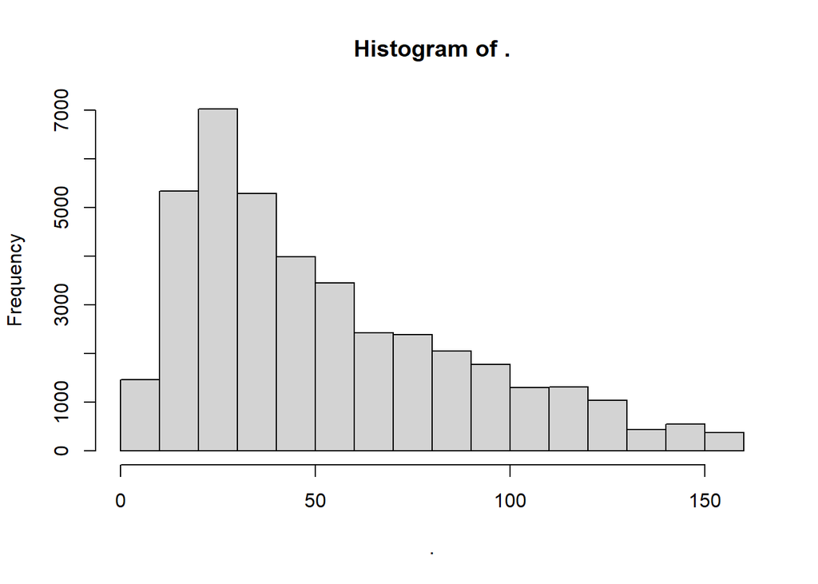

```r
train$price %>% hist()
```

```r
# 박스콕스 변환 필요성 여부
summary(powerTransform(train$price))
# 2.22e-16 < 0.05이므로 변환 필요함
set.seed(123)
p <- powerTransform(train$price)
train$price <- train$price^p$lambda
```

[output not shown]

#### **머신러닝 : LGBM**

**데이터 변환**

```r
trainX <- train %>% select(-price) %>% as.matrix()
trainY <- train %>% pull(price)
testX <- test %>% select(-price) %>% as.matrix()
testY <- test %>% pull(price)

dtrain <- lgb.Dataset(trainX, label = trainY)
dtest <- lgb.Dataset.create.valid(dtrain, data = testX, label = testY)

# validataion data
valids = list(test = dtest)
```

**파라메터 정의**

```r
lgb.grid <- list(
  objective = "regression"
  , metric = "l2"
  , min_data = 1L
   , learning_rate = .01)
```

```r
file_path <- "./rdata/"
#save.image(file=paste0(file_path, "자동차가격_upload.RData" ))
load(paste0(file_path, "자동차가격_upload.RData" ))
```

**최적 조율모수**

```r
#set.seed(123)
#cv_lgbm <- lgb.cv(params = lgb.grid,
#                  data = dtrain,
#                  nrounds = 7000,
#                  stratified = TRUE,
#                  nfold = 10)
#best_iter <- cv_lgbm$best_iter
```

```r
#model <- lgb.train(
#  params = lgb.grid
#  , data = dtrain
#  , nrounds = best_iter
#  , valids = valids)
```

**예측 및 성능평가**

```r
#pred_y_p <- predict(model, testX)
#pred_y <- pred_y_p^(1/p$lambda)

# 성능평가
postResample(pred =pred_y, obs =testY)
```

```
##      RMSE  Rsquared       MAE
## 8.8106463 0.9376181 5.7301496
```